# Welcome to the Insect Evolutionary Genomics lab at the University of Münster!

## Our Research Focus

Our work primarily aims at understanding the function and evolution of genomic complexity, currently focusing on advancing our understanding of how structural and compositional differences between genomes arise, how these differences become evident at the phenotypic level, and how selection and drift eventually produce evolutionary change.

We study genome evolutionary mechanisms at the level of species, populations and families to get a complete picture of the molecular and genetic mechanisms that allow adaptive evolution and differentiation at the level of the genome.

## Our Approach

We approach these mechanisms from two different directions:

**From an organismal perspective**, we focus on adaptive traits that emerged within a group of populations or species – for example the convergent evolution of inquiline social parasitism in fungus-growing ants. We then study phenotypic (e.g. behavioral, morphological, transcriptomic) and genetic/genomic changes underlying the adaptive change to develop models that explain how adaptation arises and is favored by selection.

**From a mechanistic perspective**, we study evolutionary mechanisms in suitable systems, focusing on mechanisms of rapid adaptive change via transposable elements (TEs), phenotypic plasticity, epigenetic inheritance, and genome rearrangements. We use model organisms that can be kept under laboratory conditions, including the ant *Cardiocondyla obscurior* and the parasitoid wasp *Aphidius ervi*.

## Our Toolkit

Our research is biased towards big data analyses, particularly comparative genomics, population genomics, and transcriptomics. However, our projects commonly involve field work for sample collection and behavioral or molecular experiments in the laboratory to support our big data findings.

We primarily focus on ants, with some projects on honey bees and parasitoid wasps, studying both rare species difficult to culture and well-suited laboratory model organisms.

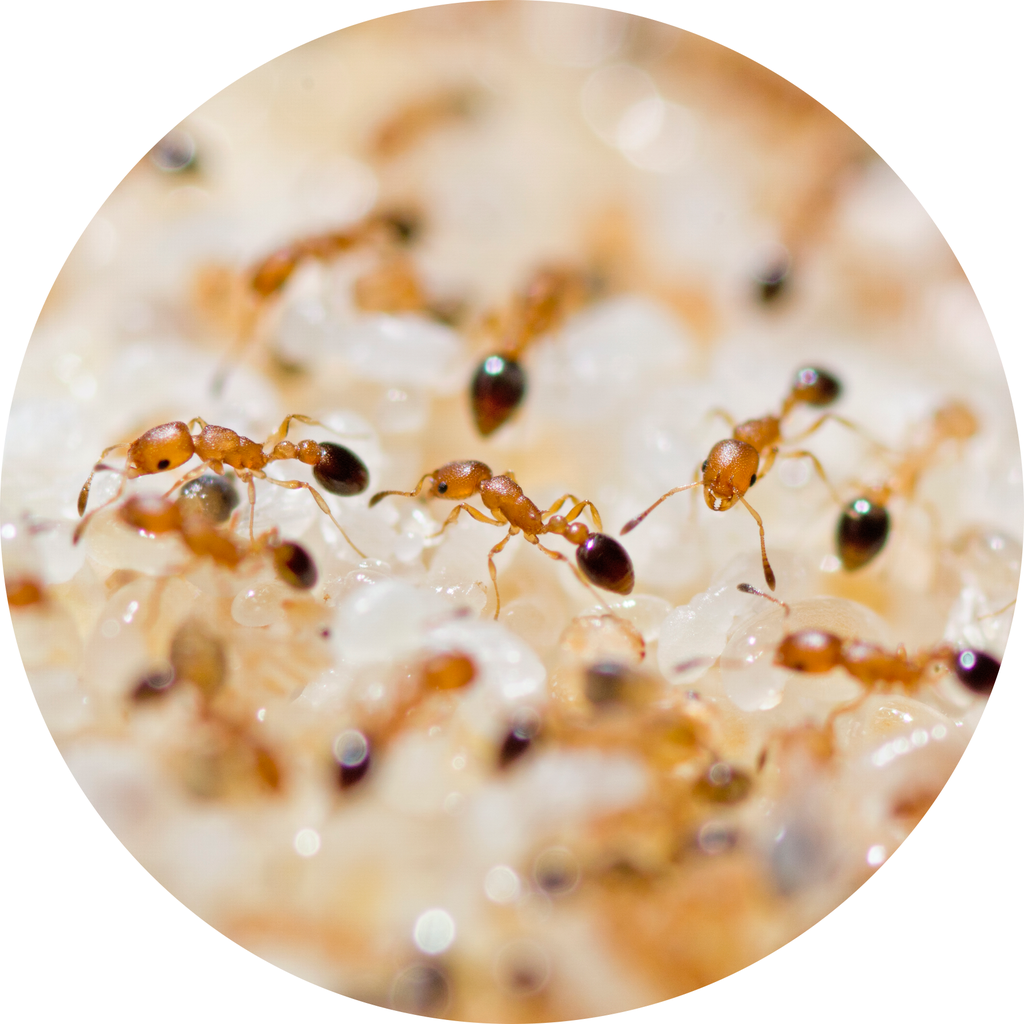

29.11.2025

Lukas and collaborators released the [AntScan paper on bioRxiv](https://www.biorxiv.org/content/10.1101/2025.11.29.689474v1.abstract), presenting high-throughput 3D X-ray imaging of 2193 ant specimens from 792 species, paired with genome data to study the evolution and diversity of organismal phenotypes.

With contributions from Simo, Janina and Lukas, [Tania’s paper on epigenetics of *Pogonomyrmex* harvester ants](https://resjournals.onlinelibrary.wiley.com/doi/full/10.1111/imb.70021) is out in Insect Molecular Biology.

10.11.2025

Isabell has joined for her Master’s thesis working on the very confusing topic of genome evolution in *Cardiocondyla*!

21.10.2025

The paper on HSP90 in Tribolium with Simo and Lukas is [published in Nature Communications](https://www.nature.com/articles/s41467-025-65027-0) now!

04.09.2025

After over 10 years of work, we have published the first paper on the GAGA project. [Read it here.](https://doi.org/10.1016/j.cell.2025.05.030)

04.09.2025

Simo and Lukas joined Wei and others in a paper on fatty acid synthase genes in *Nasonia*. See the [preprint here.](https://www.biorxiv.org/content/10.1101/2025.09.01.673505v1.abstract)

02.09.2025

Nanda Vo gracefully defended his Master’s thesis on transcriptomic signatures of plastic adaptation in Aphidius parasitoids. Congrats! 🎉

22.08.2025

Our study on adaptive evolution in ant odorant receptors is [online as a preprint!](https://www.biorxiv.org/content/10.1101/2025.08.20.670513v1.abstract)

31.03.2025

Another long-lasting project coming to an end with contributions from Simo and Lukas! [This is on HSP90 in flour beetles.](https://www.researchsquare.com/article/rs-6320655/v1)

15.03.2025

Tania’s paper with contributions by Simo, Janina and I is out on [bioarxiv](https://www.biorxiv.org/content/10.1101/2025.03.13.642958v1.abstract).

12.01.2025

Janina just posted her preprint on horizontal gene transfers in ants. This is a great paper, really! See [here](https://www.researchsquare.com/article/rs-5741203/v1).

16.12.2024

> 10 years of work in one paper. The [preprint for the Global Ant Genomics Alliance](https://papers.ssrn.com/sol3/papers.cfm?abstract_id=5055090) is online!

19.08.2024

Isabell delivered a great defense for her Bachelor’s degree today! 🎉

16.08.2024

Josh defended his Master’s thesis on molecular decanalization in *Cardiocondyla*. Congrats, Josh! 🎉

13.07.2024

[There is a new paper on Transposon Displays in *Cardiocondyla*](https://doi.org/10.1093/biomethods/bpae050). Beautiful work by Esther! 🙌

13.05.2024

Simo is on a roll. Another paper accepted, [this time in BMC Biology](https://link.springer.com/article/10.1186/s12915-024-01907-z)! We explored the evolutionary genomics of social polymorphisms in *Pogonomyrmex californicus*. 🙌

30.05.2024

Simo’s paper on recombination rate dynamics in *Cardiocondyla obscurior* was accepted in Genome Research. [Check it out here](https://genome.cshlp.org/content/34/6/863.short)! 🙌

11.04.2024

Nanda has started his Master’s thesis on the molecular signatures of host adaptation in *Aphidius ervi*. 👋

18.12.2023

Sandra defended her Master’s thesis on olfactory system evolution in ants. She will move on to do a PhD in Jena. Congrats! 🎉

13.05.2022

Janina defended her Master’s thesis on horizontal gene transfers in ants and will continue as a PhD student. Congrats, and welcome! 🎉👋

08.04.2022

Esther defended her Master’s thesis on phenotypic robustness, TEs and heatshocks in *Cardiocondyla*. Esther will stay on as a PhD student. Congrats, and welcome! 🎉👋

28.01.2022

Our website has gone online. Check out our team and an overview of all published papers.

05.01.2022

The DFG-funded project on “Transposable elements as genetic innovators in the invasive ant *Cardiocondyla obscurior*” will start soon!

Copyright © 2021 Lukas Schrader